# Geoconnex Structured Metadata Guidance

## Introduction

The Geoconnex project is about providing technical infrastructure and guidance to create an open, community-contribution model for a knowledge graph linking hydrologic features in the United States, published in accordance with [Spatial Data on the Web best practices](https://www.w3.org/TR/sdw-bp/) as an implementation of [Internet of Water](https://github.com/opengeospatial/SELFIE/blob/master/docs/demo/internet_of_water.md) principles.

Geoconnex aims to enable a [knowledge graph](https://en.wikipedia.org/wiki/Knowledge_graph) for water data in the United States. The value of this graph, (see `https://graph.geoconnex.us`) can be illustrated considering two use cases:

1. Indexing and discovering models and research from public sector, private sector, or academic projects about a particular place or environmental feature.
2. Building a federated multi-organization monitoring network in which all member-systems reference common monitored features and are discoverable through a community index.

In other words, Geoconnex will allow data users to answer questions like: “What datasets are available about the portions of Colorado River upstream of Lake Mead within Nevada and Utah regarding variables discharge and total suspended solids with measurements taken at least daily with coverage between 2002 and 2007?” and be returned metadata for all relevant datasets from all participating organizations, including federal, state, private, and NGO organizations.

See https://geoconnex.us/demo for a mockup of data discovery and access workflows that `https://geoconnex.us` aspires to enable.

The development of geoconnex.us takes place on GitHub. See [here](https://github.com/internetofwater/about.geoconnex.us) for the system of repositories.

This capability rests on data providers publishing metadata to the system. Thus, Geoconnex involves the publication of metadata within websites that describe water datasets and the real-world environmental features (eg rivers, wells, dams, catchments) or the cataloging features (eg government jurisdiction areas, statiscal summary reporting areas) that they are relevant to. This document provides guidance, including general principles as well as specific templates, for data providers for how to structure this metadata using the JSON-LD format.

**Related materials, presentations, and publications**

[National Hydrography Infrastructure and Geoconnex](https://drive.google.com/file/d/1J0NKYOq3pGjQXr58FKO8sd7uHpGA8kNB/view?usp=sharing)

[New Mexico Water Data Initiative including geoconnex.us](https://docs.google.com/presentation/d/1yuNpBbQPcmb_Nw8DXiuNTazAjIM8UF7o/edit?usp=sharing&ouid=102421334323378854304&rtpof=true&sd=true)

[Roundtable presentation including geoconnex.us](https://www.westernstateswater.org/wp-content/uploads/2020/06/CO_Roundable_IoW.pdf)

[Second Environmental Linked Features Interoperability Experiment](https://github.com/opengeospatial/SELFIE)

[ESIP Sessions on Structured Data in the Web](https://2020esipsummermeeting.sched.com/event/cIvv/structured-data-on-the-web-putting-best-practice-to-work) [slides](https://docs.google.com/presentation/d/1LSXHz2_Y7hrkGZPC_sNoJWl8AIujI8AAWktl9amIR4E/edit#slide=id.g8250495469_1_30)

### Basic Information Model

The model used to organize information in the Geoconnex system is shown in Figure 1.

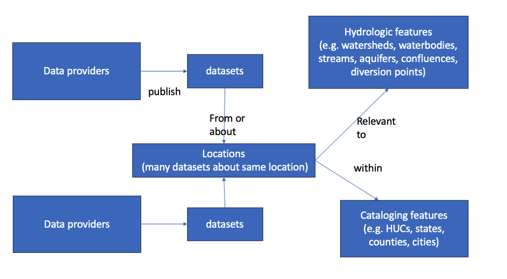

Figure 1: Basic information model for resources in geoconnex

- **Data providers** refer to specific systems that publish water-related **datasets** on the web. Many times a provider will simply be the data dissemination arm of an organization, such as the [Reclamation Information Sharing Environment (RISE)](https://data.usbr.gov) of the US Bureau of Reclamation. Some organizations may have multiple data providers, such as US Geological Survey, which administers the [National Water Information System](https://waterdata.usgs.gov) as well as the [National Groundwater Monitoring Network](https://cida.usgs.gov/ngwmn/), among others. Some data providers are aggregators of other organizations’ data, such as the [Hydrologic Information System](https://data.cuahsi.org) of CUAHSI.
- **Datasets** refer to specific collections of data that are published by data providers. In the context of Geoconnex, a single dataset generally refers to one that is collected from, or summarizable to, a specific spatial **location** on earth, as part of a specific activity. For example, a dataset would be the stage, discharge and water quality sensor data coming from a single stream gage, but not the collection of all stream gage readings from all stream gages operated by a given organization. A dataset could also be the time-series of a statistical summary of water use at the county level.
- **Locations** are specific locations on earth that datasets are collected from or about, such as stream gages, groundwater wells, and dams. In the case of data that is reported at a summary unit such as a state, county, or hydrologic unit code (HUC), these can also be considered Locations. Conceptually, multiple datasets from multiple providers can be about the same Location, as might occur when a USGS streamgage and a state DEQ water quality sampling site are both located at a specific bridge.
- **Hydrologic features** are elements of the water system that are related to locations. For example, a point may be on a river, which is within a watershed, and whose flow influences an aquifer. Each of these are distinct, identifiable features which many Locations are hydrologically related to, and which a user of a given dataset might also want to use.
- **Cataloging features** are areas on earth that commonly group datasets. They are a superset of summary features such as HUCs, counties and states. For example, a state-level dataset summarizing average annual surface water availability would not have states as a cataloging feature. However, streamgage is within a state, county, HUC, congressional district, etc and may be tagged with these features in metadata, and thus be filtered alongside other streamgages within the same state.

This Geoconnex guidance concerns how to explicitly publish metadata that describes Datasets how they are related to each of the other elements of the information model.

### JSON-LD

JSON-LD is a version of JSON, the popular data exchange format used by web APIs, to express linked data. Linked Data is an approach to data publication that allows data from various sources to be easily integrated. JSON-LD accomplishes this by mapping terms from a source data system to a machine-readable definition of that term available on the web, allowing different attribute names from different data sources to be consistently interpreted together. Commonly, JSON-LD is embedded within websites, allowing search engines and applications to parse the information available from web addresses (URLs). For an in-depth exploration and multimedia resources, refer to the [JSON-LD official site](https://json-ld.org) and its [learning section](https://json-ld.org/learn.html). A brief overview of the JSON-LD format follows below.

Below is an example JSON-LD document, with an explanation of its major elements.

```json
{
  "@context": {
    "schema": "https://schema.org/",
    "ex": "https://example.com/schema/"
  },
  "@id": "https://example.com/well/1234",
  "@type": "schema:Place",
  "name": "Well 1234",
  "description": "Well at 1234 Place St., USA",
  "subjectOf": {
    "@id": "https://datasystem.org/dataset1",
    "@type": "schema:Dataset",
    "name": "Well Locations Dataset",
    "ex:recordCount": 500
  }
}
```

**`@context`** The `@context` keyword in JSON-LD sets the stage for interpreting the data by mapping terms to IRIs (Internationalized Resource Identifiers). By doing so, properties and values are clearly defined and identified. Our updated example has two contexts:

- `schema`: Refers to `https://schema.org/`, which is a standard vocabulary for web-based structured data.
- `ex`: This is a custom context representing `https://example.com/schema/`, potentially signifying specific extensions or custom data definitions specific to our website.

**`@id`** The `@id` keyword furnishes a unique identifier for subjects in the JSON-LD document, enabling the subjects to be interconnected with data elsewhere. In this example:

- Well 1234 has the identifier `https://example.com/well/1234`.
- The dataset that it is about, “Well Locations Dataset”, has its unique identifier as `https://datasystem.org/dataset1`.

**`@type`** The `@type` keyword stipulates the type or nature of the subject or node in the JSON-LD. It aids in discerning the entity being depicted. In the given context:

- Well 1234 is specified as a “Place” from the schema.org vocabulary (`schema:Place`).
- Well Locations Dataset’s type is a “Dataset” from the schema.org vocabulary (`schema:Dataset`).

**Nodes** Nodes represent entities in JSON-LD, with each entity having properties associated with it. In the example:

- The main node is Well 1234, possessing properties like “name”, “description”, and “subjectOf”.
- subjectOf property itself is a node representing a dataset that is about Well 1234. Apart from the “name” property, the dataset now also has a property called “ex:recordCount”, indicating the number of rows in the dataset.

This extension showcases the flexibility and strength of JSON-LD, where you can seamlessly integrate standard vocabulary with custom definitions, ensuring rich and well-structured interconnected data representations.

## Building Blocks

A Geoconnex JSON-LD document has several building blocks:

#### Context

### Reference Features

#### Reference Monitoring Features

#### Reference Hydrologic Features

#### Reference Cataloging Features

### Organizational Monitoring Features

#### Surface Water

#### Groundwater

#### Non-hydrological

### Datasets

#### Variables

#### Temporal Extent

#### Temporal Resolution

#### Data generation process

#### Spatial extent and resolution (gridded data only)

#### Provenance

#### Data access

## Complete Examples

### Monitoring location page (minimal)

### Monitoring location page (full)

### Dataset (minimal)

### Dataset (full)

## Future work

Fully semantic data

[output not shown]